# Introduction

**Write FPGA logic in Julia, run it in Julia, compile it to Verilog.**

## Why another HDL?

Algorithmic logic in an FPGA often is a port from an implementation in Julia or Python or MATLAB, rewritten as hardware. Porting and testing can be tricky, and debugging the Verilog implementation can be painful. Wouldn’t it be nice if we could just write the hardware description in Julia, pass it inputs and compare the outputs directly from Julia, and poke at various wires in the hardware description from a Julia REPL?

That’s what QuartzHDL allows you to do!

QuartzHDL keeps the design in the language the reference is written in. A module is a `struct` whose fields are the registers, with a block that says how those registers behave at every clock edge. The same source runs as ordinary Julia — one function call per clock, values you can inspect and test — and compiles to Verilog. A co-simulation drives both versions with the same stimulus and checks that they agree, cycle for cycle, so that the compiled Verilog is tested to be a faithful port of the Julia version.

**NoteWhat QuartzHDL is not**

QuartzHDL is not a Julia-to-hardware compiler and not a replacement for Verilog. It is Verilog’s subset of synchronous logic, written in a language with types, a REPL, a test framework and a plotting library, so that a design can be debugged like software, ported from a reference one step at a time, tested against models of the chips around it, and checked on every push. If you know how to write an `always @(posedge clk)` block, you already know most of what QuartzHDL lets you say.

It also provides higher level design patterns — finite state machines, metaguards, pipelined computations, multicycle logic and the like — that form a foundation for many designs, but are painful to implement by hand in Verilog.

## Features at a glance

- **Hardware description** as a Julia `struct`, with fields as interface wires and registers, and methods as behavior.
- **Primitive data types** – `Bool` (active high/low polarity), `Bits{N}` and `SBits{N}`.
- **Board level I/O** – `Pads` with tri-state machinery, pull-ups / pull-downs, voltage definitions and pin bindings.
- **Hierarchical designs** – constructed by wiring up submodules, clock domains, power-gated pads, and vendor black boxes.
- **Hardware idioms** as foundational building blocks – metaguards, self-clearing pulses, countdown timers, edge detectors, finite state machines, multi-step sequences, multi-cycle settling combinatorial logic, etc.
- **Runs as plain Julia** — one function call per clock edge, tested with `@test` and debugged at the REPL.
- **Simulation** with peripheral logic — real clock rates, models of a USB FIFO, UART, SPI, I2C and RAM, stand-ins for black boxes, live waveforms in Surfer or `Plots`, and a `sim>` custom REPL.
- **Compiles to Verilog** – co-simulated using Icarus Verilog to ensure that Julia and Verilog outputs match cycle for cycle.
- **Board to bitstream** — `@board` describes the pins, and the constraint file and a Lattice Diamond workspace are generated from it.

## Installation

```julia
using Pkg
Pkg.add("QuartzHDL")           # Julia 1.11 or later
Pkg.Apps.add("QuartzHDL")      # the `quartz` command; Julia 1.12 or later
```

Some features need tools on your path, and the manual says so where it uses them: [Icarus Verilog](https://steveicarus.github.io/iverilog/) (`iverilog`, `vvp`) for co-simulation, and [Surfer](https://surfer-project.org) for live waveforms. On a Mac with Homebrew, `brew install icarus-verilog surfer` gets both.

## An example

A UART transmitter: a byte in, a serial frame out with a parity bit. The frame is a sequence of steps, each one clock; the bit timing is a countdown register and the start strobe is an edge detector, each doing its own bookkeeping.

```julia
using QuartzHDL

const BIT_TIME = 9                   # clocks per bit, less one: 100 kbaud from 1 MHz

@quartz struct UartTx
  # interface wires
  @in  data::Bits{8}                 # 8-bit data to transmit
  @in  send::Bool                    # on rising edge of send
  @in  rst::Bool active=:low         # reset signal, asserted low
  @out tx::Bool = true               # TX pin of the UART
  @out busy::Bool active=:low        # busy signal, asserted low
  # internal state
  step::Bits{5} = 0                  # state machine step counter
  send_e::Edge                       # edge detector for send input
  shift::Bits{8}                     # transmit shift register
  parity::Bool                       # parity bit
  baud_timer::Timeout{7}             # timer to control baud rate
end

@on UartTx posedge(clk) begin
  @reset(rst)                        # reset module when rst is asserted
  send_e ← send
  @sequence Frame step begin
    @when rose(send_e)               # wait for a send strobe, then
    shift ← data
    parity ← isodd(popcount(data))   # a Julia function, computed in hardware
    tx ← false                       # start bit
    baud_timer ← BIT_TIME
    @repeat 8 begin
      @when expired(baud_timer)      # one bit time later
      tx ← shift[0]                  # a data bit, LSB first
      shift ← shift >> 1
      baud_timer ← BIT_TIME
    end
    @then @when expired(baud_timer)
    tx ← parity                      # transmit parity bit
    baud_timer ← BIT_TIME
    @then @when expired(baud_timer)
    tx ← true                        # stop bit
    baud_timer ← BIT_TIME
    @then @when expired(baud_timer)  # hold it, then back to waiting for send
  end
  busy ← step != Frame.START
end
```

The `@quartz struct` declares the ports and the registers. `@on` says what happens on each rising edge of `clk`: `←` is a register write that lands at the end of the cycle, exactly like Verilog’s `<=`.

It is ordinary Julia, so it runs as such. A simulation clocks it at a real rate, records the pins you ask for, and hands back signals you can index by time, test, and plot:

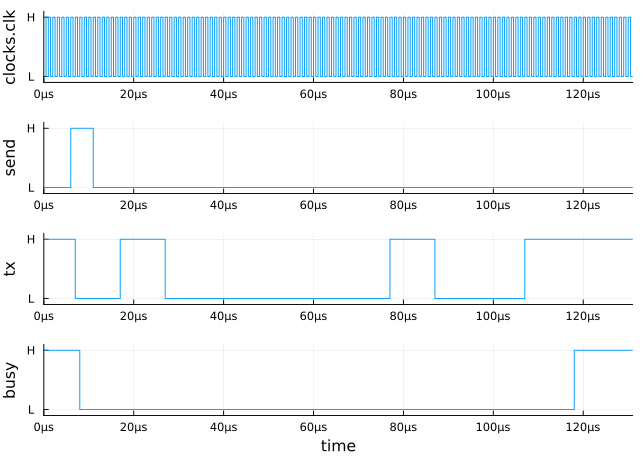

```julia
using QuartzHDL.Units, Plots

sim = Simulation(UartTx(); clocks=(clk=1MHz,), watch="*")
out = @run sim begin
  sim.data = Bits{8}('A')
  advance_by(5µs)                   # a few clocks in, strobe send
  sim.send = true
  advance_by(5µs)
  sim.send = false
  advance_by(120µs)
end
plot(out, "clk", "send", "tx", "busy")
```

The same file compiles to Verilog from the command line — a `case` over the sequence’s steps, the state machine you would have written by hand:

```
$ quartz uart.jl --top UartTx -o uart.v
```

Or from Julia, writing the module type out:

```julia
write(stdout, UartTx, Verilog());
```

```
module UartTx (
  input wire clk_i,
  input wire send_i,
  input wire [7:0] data_i,
  input wire rst_ni,
  output wire tx_o,
  output wire busy_no
);

  localparam [4:0] Frame_START = 5'h0;
  localparam [4:0] Frame_step_1 = 5'h1;
  localparam [4:0] Frame_step_2 = 5'h2;
  localparam [4:0] Frame_step_3 = 5'h3;
  localparam [4:0] Frame_step_4 = 5'h4;
  localparam [4:0] Frame_step_5 = 5'h5;
  localparam [4:0] Frame_step_6 = 5'h6;
  localparam [4:0] Frame_step_7 = 5'h7;
  localparam [4:0] Frame_step_8 = 5'h8;
  localparam [4:0] Frame_step_9 = 5'h9;
  localparam [4:0] Frame_step_10 = 5'ha;
  localparam [4:0] Frame_step_11 = 5'hb;

  wire clk = clk_i;
  wire send = send_i;
  wire [7:0] data = data_i;
  wire rst = ~rst_ni;
  reg tx;
  reg busy;
  reg [4:0] step;
  reg send_e;
  reg send_e_prev;
  reg [7:0] shift;
  reg parity;
  reg [6:0] baud_timer;

  wire w11 = baud_timer == 7'h0;
  wire [6:0] w13 = baud_timer - 7'h1;
  wire [6:0] w14 = w11 ? baud_timer : w13;
  wire w16 = step == Frame_START;
  wire w19 = ~send_e_prev;
```

[output cut: 140 more lines]

```
          if (w82) begin
            step <= Frame_START;
          end
        end
        default: begin
          step <= Frame_START;
        end
      endcase
      busy <= w84;
    end
  end

  assign tx_o = tx;
  assign busy_no = ~busy;
endmodule
```

That is the whole loop: describe, simulate, compile. The rest of this manual walks through it slowly.

## Where to go next

- Quickstart builds a small design end to end: write it, simulate it, test it against the generated Verilog.
- **Writing hardware** covers the language a construct at a time, starting with modules and registers.
- **Going further** adds the constructs that make real designs short: pulses, timeouts and edges, clock domains, pipelines, multicycle paths, submodules and black boxes.
- **Simulating** covers driving a simulation, benches, waveforms and plots, the component library and tests and CI.
- **Building** covers Verilog output and boards and constraints.
- **Extending** shows how to write custom components and custom emitters.
- The appendices hold a side-by-side with Verilog, the rules the compiler enforces, a look under the hood, and the API reference.

**TipIf you know Verilog**

Boxes like this one appear throughout the manual to point out where QuartzHDL differs from what a Verilog author would expect.